# Data Visualization with ggplot2

Author

David Nganga

Published

September 12, 2026

## Notebook Objectives

- Understanding the **code structure** for ggplot plots
- Understanding **layers of ggplot objects**
- Adding **labels and captions** of ggplot objects
- Understanding **aesthetics** of ggplot objects
- Knowing the difference between **mapping & setting aesthetics**

### Loading packages

```r
library(palmerpenguins)
library(tidyverse)
library(skimr)
library(knitr)
```

## The ggplot2 package

Its the most popular **Data Visualization** package in R.

## ggplot2 Structure of code

The structure of the code for ggplot2 objects is of the form:

” ggplot(data = [dataset],  
mapping = aes(x = [x-variable],  
y = [y-variable] )) +  
geom_xxx() +  
other options ”

## Example: Palmer Penguins data

The Palmer Penguins data set contains data on 344 penguins from 3 islands in [Palmer Archipelago, Antarctica](https://www.google.com/maps/place/Palmer+Archipelago/@-64.1463814,-62.1800963,7z/data=!3m1!4b1!4m5!3m4!1s0xbc78dd6dc38c572b:0xe609367aeed33087!8m2!3d-64.1957848!4d-62.0153384).

### Palmer penguins data summary

| Variable | Description |
| --- | --- |
| species | Species of the penguin |
| island | Island the penguin was found on |
| bill_length_mm | Bill length (mm) |
| bill_depth_mm | Bill depth (mm) |
| flipper_length_mm | Flipper length (mm) |
| body_mass_g | Body mass (g) |
| sex | Sex of the penguin |
| year | Year data was collected |

➡️ First, let’s **load the Palmer Penguins data set** and explore some high-level characteristics of the data set using the code below:

```r
data(penguins, package = "palmerpenguins")
```

we can glimpse our data to start. (In R, **`glimpse()`** is a function from the **`dplyr`** package (part of the **`tidyverse`**) that gives you a quick, transposed preview of your dataset ).

```r
glimpse(penguins)
```

```
Rows: 344
Columns: 8
$ species           <fct> Adelie, Adelie, Adelie, Adelie, Adelie, Adelie, Adel…
$ island            <fct> Torgersen, Torgersen, Torgersen, Torgersen, Torgerse…
$ bill_length_mm    <dbl> 39.1, 39.5, 40.3, NA, 36.7, 39.3, 38.9, 39.2, 34.1, …
$ bill_depth_mm     <dbl> 18.7, 17.4, 18.0, NA, 19.3, 20.6, 17.8, 19.6, 18.1, …
$ flipper_length_mm <int> 181, 186, 195, NA, 193, 190, 181, 195, 193, 190, 186…
$ body_mass_g       <int> 3750, 3800, 3250, NA, 3450, 3650, 3625, 4675, 3475, …
$ sex               <fct> male, female, female, NA, female, male, female, male…
$ year              <int> 2007, 2007, 2007, 2007, 2007, 2007, 2007, 2007, 2007…
```

Activity1:

## ggplot2 data visualization steps

**visualizing the relationship between the bill depth of the penguins (mm) and the bill lengths (mm) of the penguins.**

[aesthetics](https://ggplot2.tidyverse.org/articles/ggplot2-specs.html) is used in data visualizations to differentiate between subgroups or to show additional dimensions of the data by mapping **characteristics to a variable** such as color, shape or size.

### Plot in layers

ii_ adding bill depth to the **x-axis**.

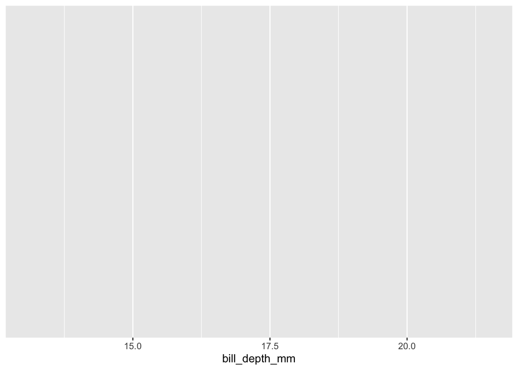

```r
penguins |>
  ggplot(aes(x=bill_depth_mm)   )
```

iii_ adding bill length to the **y-axis**.

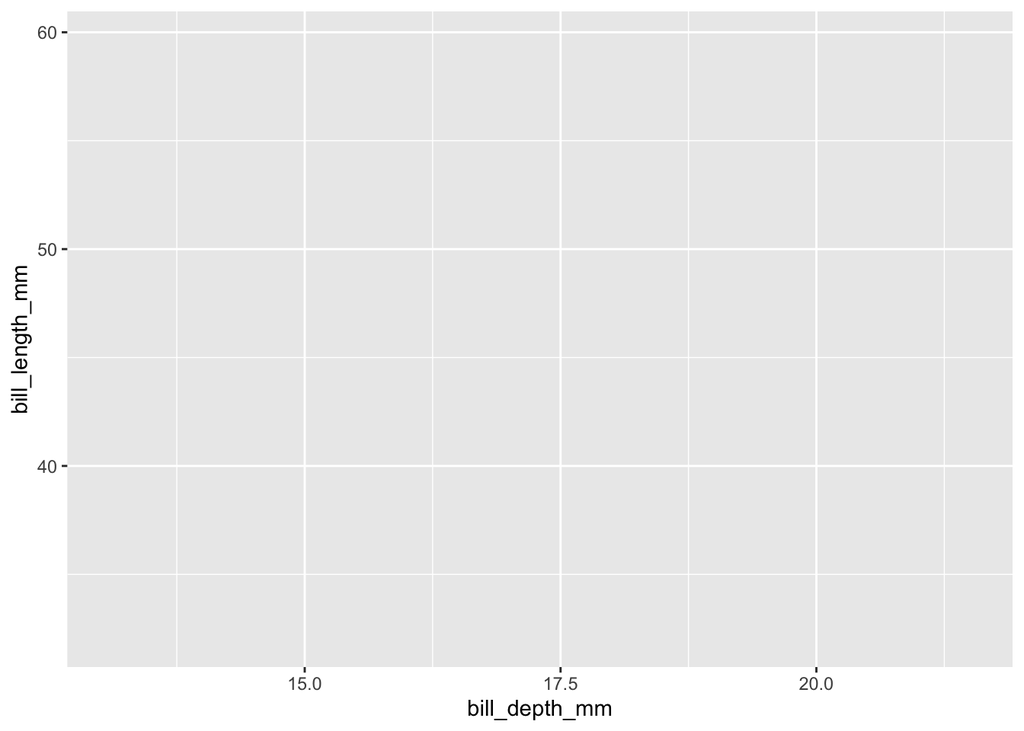

```r
penguins |>
  ggplot( aes(x=bill_depth_mm, y=bill_length_mm  ) )
```

iv_ adding **points** using **geom_point()** to the plot to create **scatter plot**. (Additional layers are added to a ggplot using the + operator).

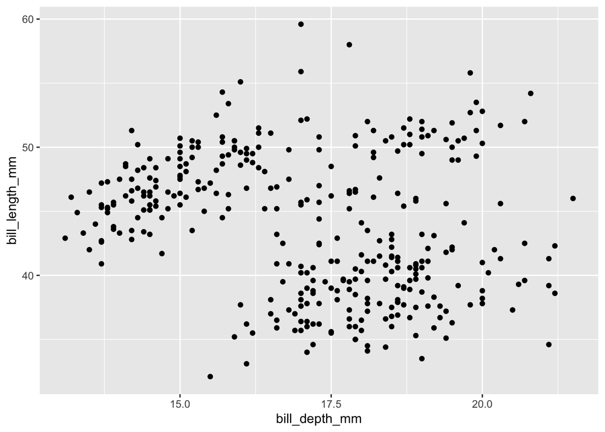

```r
penguins |>
  ggplot( aes(x=bill_depth_mm, y=bill_length_mm) )+
  geom_point()
```

v_ adding **color to the points** using **color()** in our scatter plot **based on the species of the penguin** being Adelie, Chinstrap, or Gentoo, reproducing the plot below.

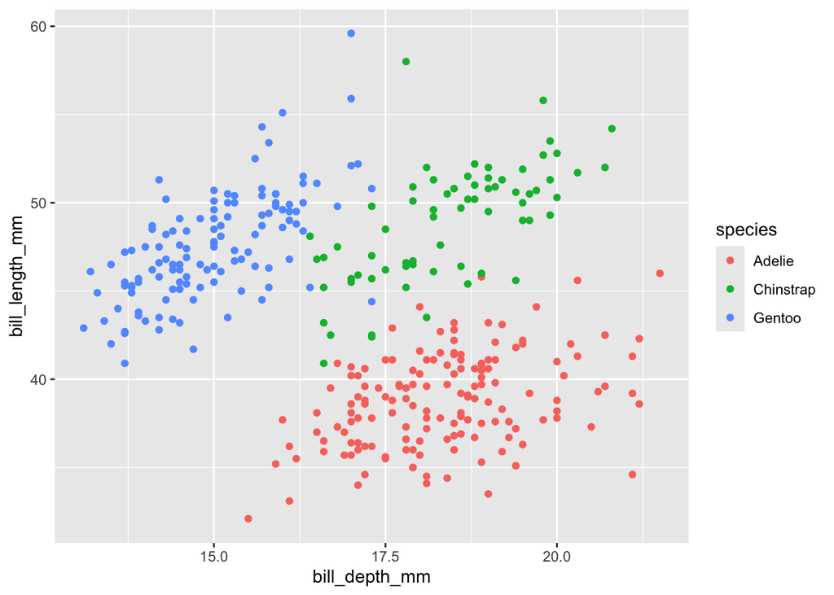

```r
penguins |>
  ggplot(aes(x=bill_depth_mm,
             y=bill_length_mm,
             color= species))+
geom_point()
```

vi_ adding another layer to our ggplot to customize the **Title and Subtitle** using the **labs()** function to reproduce the plot below.

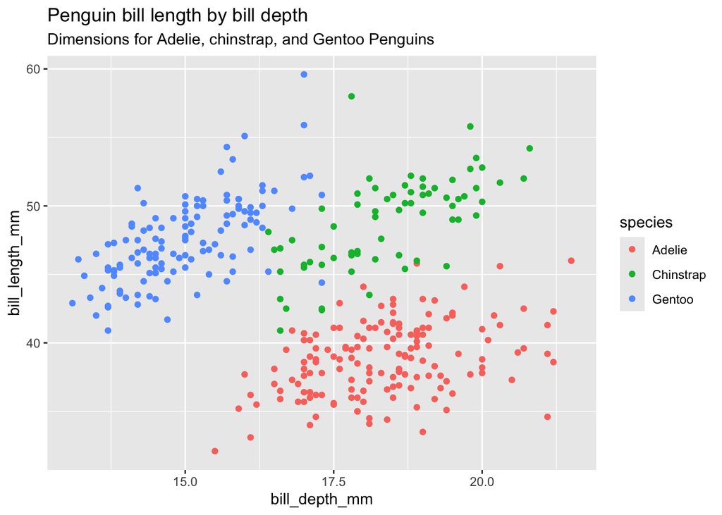

```r
penguins |>
  ggplot(aes(x=bill_depth_mm,
             y=bill_length_mm,
             color= species))+
  geom_point()+
  labs(title="Penguin bill length by bill depth",
       subtitle = "Dimensions for Adelie, chinstrap, and Gentoo Penguins")
```

Activity2:

## ggplot2 customization

i_ ➡️ Customizing the axis labels using the *x and y options* in the **labs() function**.

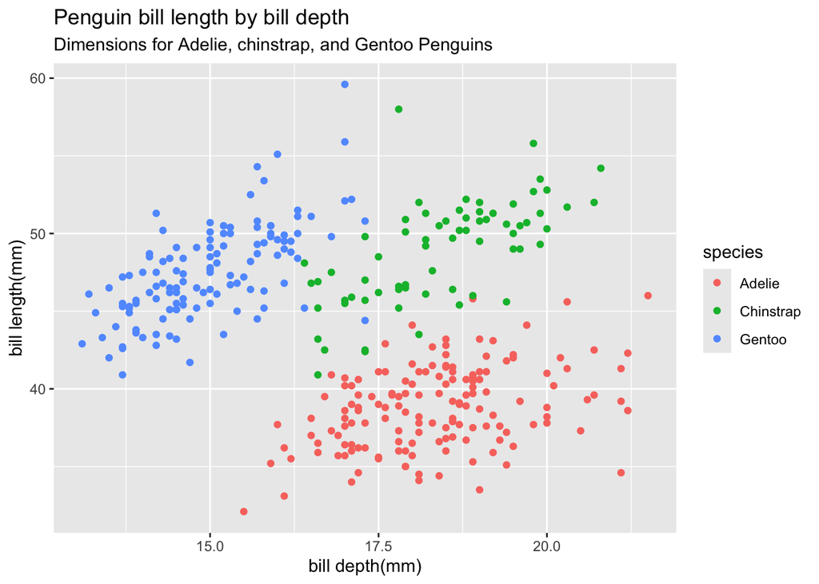

```r
penguins |>
  ggplot(aes(x=bill_depth_mm,
             y=bill_length_mm,
             color= species))+
  geom_point()+
  labs(title="Penguin bill length by bill depth",
       subtitle = "Dimensions for Adelie, chinstrap, and Gentoo Penguins",
       x="bill depth(mm)",
       y="bill length(mm)" )
```

ii_ ➡️ Customize the legend title to be “Species” instead of “species”

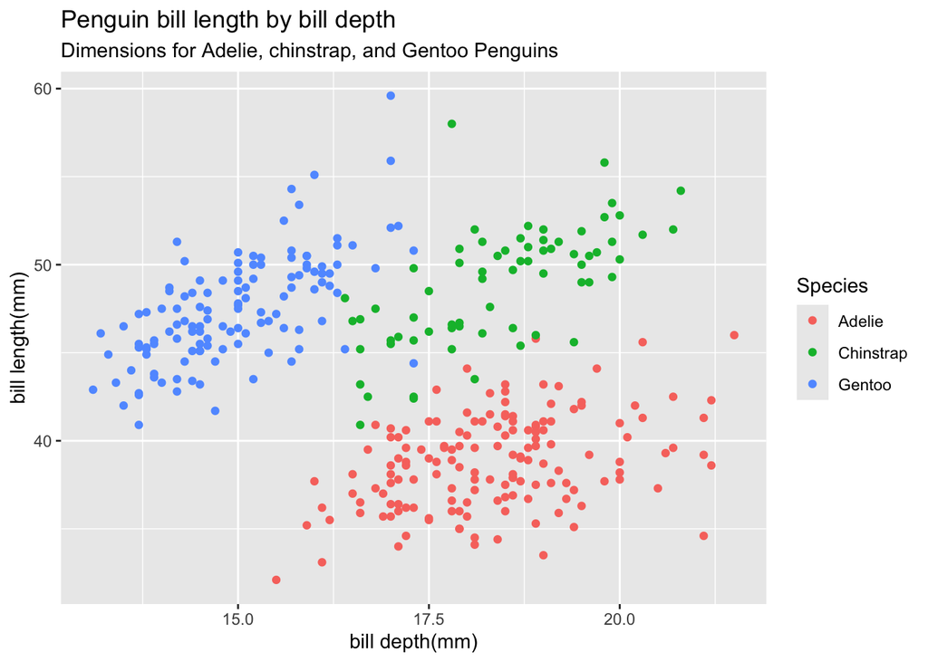

```r
penguins |>
  ggplot(aes(x=bill_depth_mm,
             y=bill_length_mm,
             color= species))+
  geom_point()+
  labs(title="Penguin bill length by bill depth",
       subtitle = "Dimensions for Adelie, chinstrap, and Gentoo Penguins",
       x="bill depth(mm)",
       y="bill length(mm)",
       color= "Species")
```

iii_ ➡️ Adding caption which may explain source of data

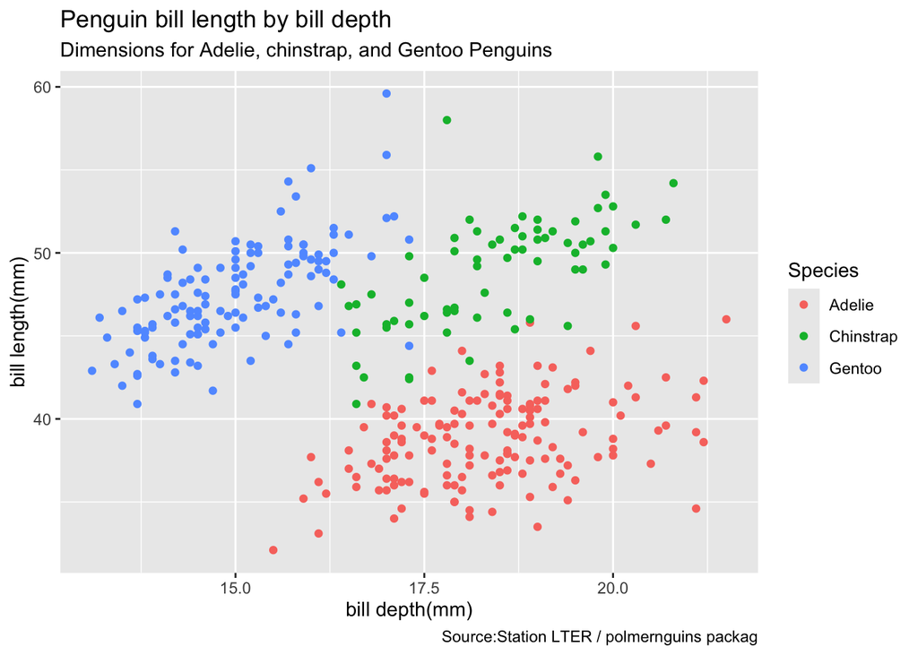

```r
penguins |>
  ggplot(aes(x=bill_depth_mm,
             y=bill_length_mm,
             color= species))+
  geom_point()+
  labs(title="Penguin bill length by bill depth",
       subtitle = "Dimensions for Adelie, chinstrap, and Gentoo Penguins",
       x="bill depth(mm)",
       y="bill length(mm)",
       color= "Species",
       caption = "Source:Station LTER / polmernguins packag" )
```

iii_ ➡️ Lastly, use a **discrete color scale** that is inclusive of viewers with common forms of color blindness by adding a **scale_color_viridis_d()** layer to the plot, creating the final plot below.

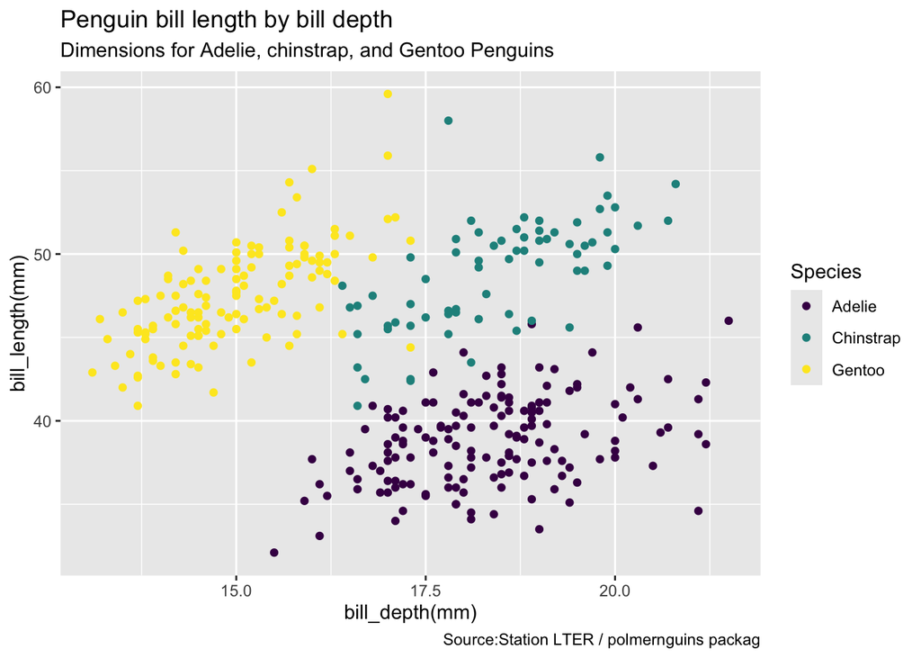

```r
penguins |>
  ggplot(aes(x=bill_depth_mm,
             y=bill_length_mm,
             color= species))+
  geom_point()+
  labs(title="Penguin bill length by bill depth",
       subtitle = "Dimensions for Adelie, chinstrap, and Gentoo Penguins",
       x="bill_depth(mm)",
       y="bill_length(mm)",
       color="Species",
       caption = "Source:Station LTER / polmernguins packag") +
  scale_color_viridis_d()
```

Congrats! 🎨 🎉 🥳 now created a visualization using ggplot2!

### Mapping vs Setting

**Mapping** in ggplot2 is the process of using aesthetics in a visualization to show **additional variables** from a data set

For example, in the plot below, **body_mass_g** is mapped to the **size** aesthetic.

i_ mapping **body_mass_g** to the **size** aesthetic.

When we say **`body_mass_g`** is mapped to the size aesthetic, it means that the **visual size of each dot** on the plot is determined by **how heavy** that individual penguin is.

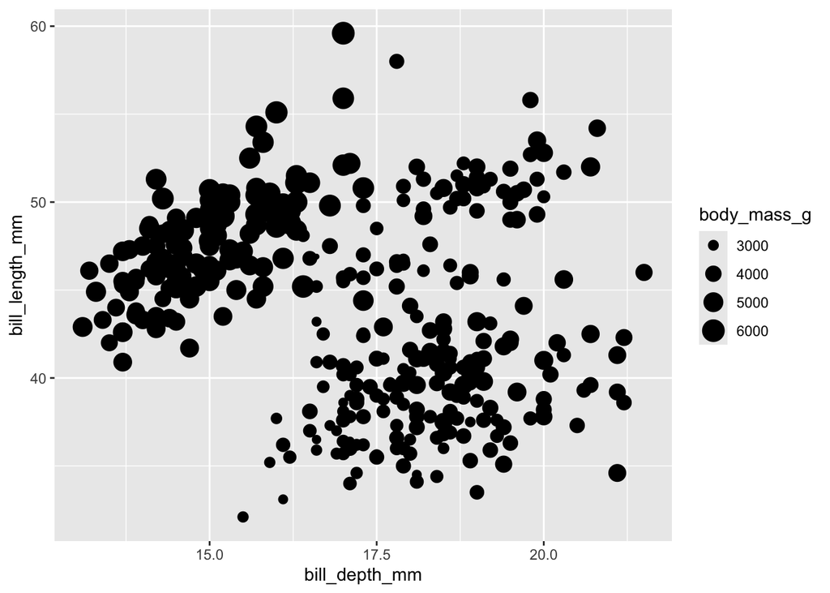

```r
ggplot(penguins,
       aes(x = bill_depth_mm,
           y = bill_length_mm,
           size = body_mass_g)) +
  geom_point()
```

ii_ mapping **flipper_length_mm** to the **alpha** aesthetic.

When we say **`flipper_length_mm`** is mapped to the alpha aesthetic, it means that **the transparency of each dot on the plot is determined by the length of that penguin’s flippers**.

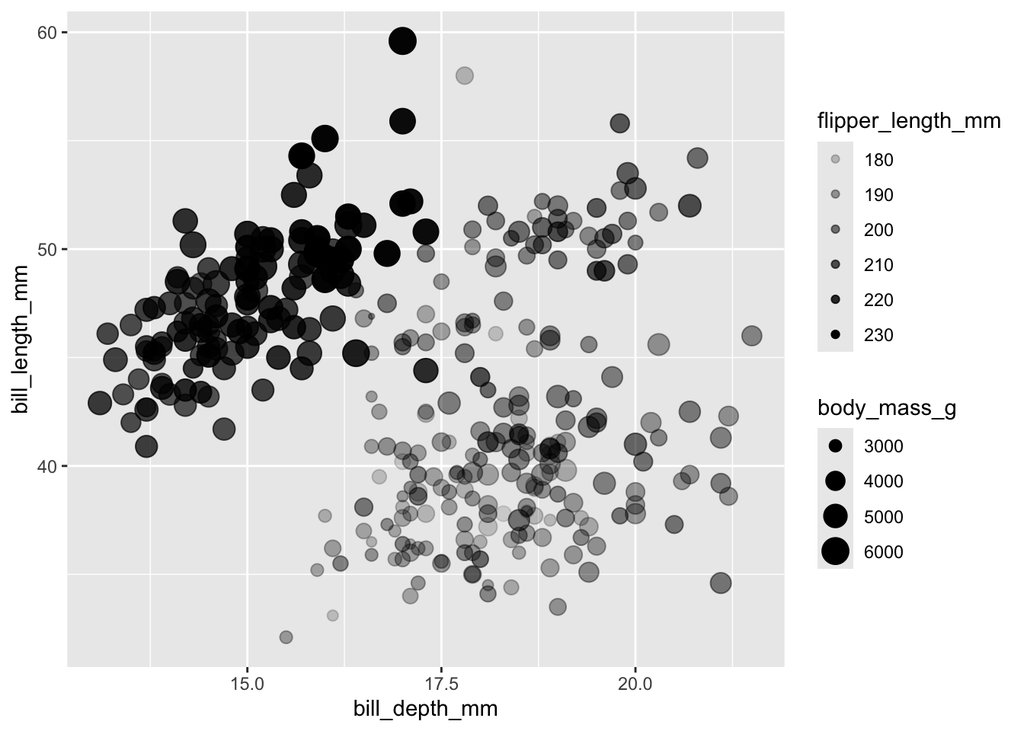

```r
ggplot(penguins,
       aes(x = bill_depth_mm,
           y = bill_length_mm,
           size = body_mass_g,
           alpha= flipper_length_mm)) +
  geom_point()
```

### Setting

**Setting** in ggplot2 is the process of manually specifying aesthetics for a visualization based on fixed values for all observations.

i_ set the value of aesthetic to 2

When we say **`size = 2`** sets the value of the aesthetic, it means you are manually forcing **every single dot on the plot to have a fixed, identical size**, completely ignoring any variables in the data.

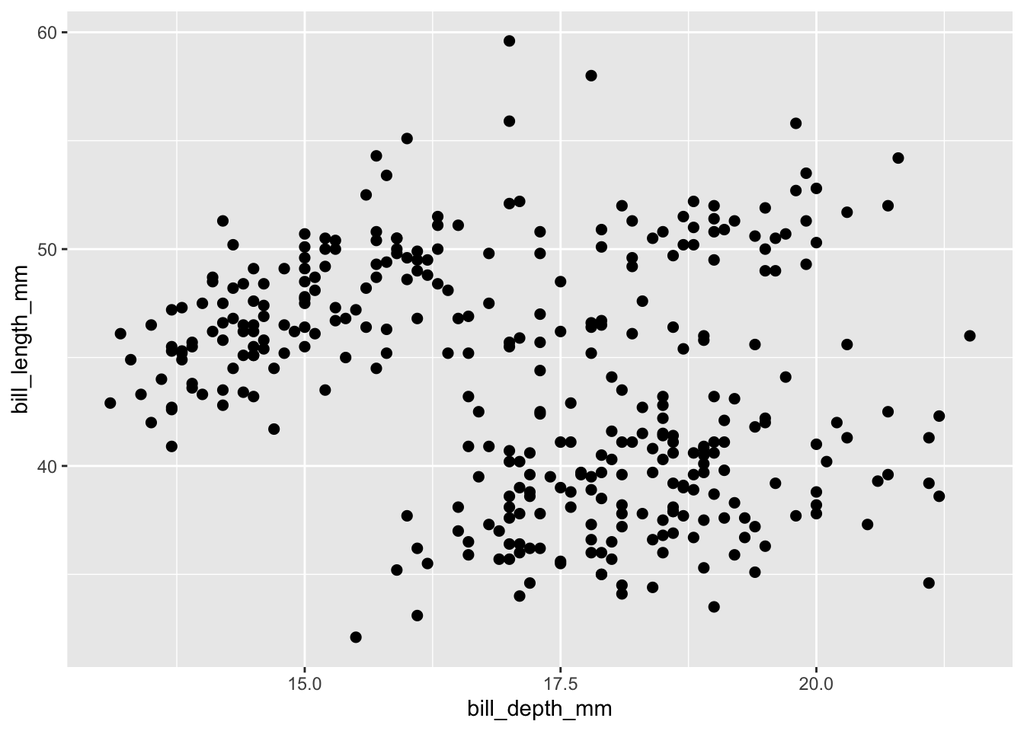

```r
ggplot(penguins,
       aes(x = bill_depth_mm,
           y = bill_length_mm)) +
  geom_point(size = 2)
```

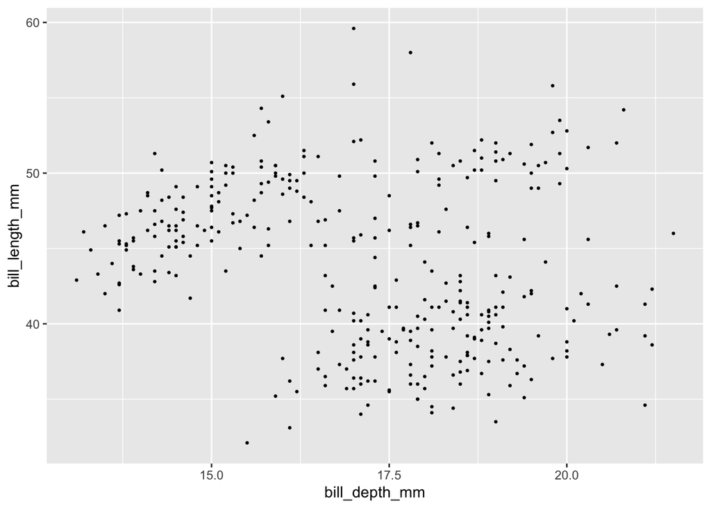

```r
ggplot(penguins,
       aes(x = bill_depth_mm,
           y = bill_length_mm)) +
  geom_point(size = 0.50)
```

Question 1:

➡️ Is there any missing data? yes, the is a warning for missing values.

What is the plot doing with the missing values? Hint: consider using the skim() function from the skimr package to assess missingness.

```r
skim(penguins)
```

Data summary

| Name | penguins |
| --- | --- |
| Number of rows | 344 |
| Number of columns | 8 |
| _______________________ |  |
| Column type frequency: |  |
| factor | 3 |
| numeric | 5 |
| ________________________ |  |
| Group variables | None |

**Variable type: factor**

| skim_variable | n_missing | complete_rate | ordered | n_unique | top_counts |
| --- | --- | --- | --- | --- | --- |
| species | 0 | 1.00 | FALSE | 3 | Ade: 152, Gen: 124, Chi: 68 |
| island | 0 | 1.00 | FALSE | 3 | Bis: 168, Dre: 124, Tor: 52 |
| sex | 11 | 0.97 | FALSE | 2 | mal: 168, fem: 165 |

**Variable type: numeric**

| skim_variable | n_missing | complete_rate | mean | sd | p0 | p25 | p50 | p75 | p100 | hist |
| --- | --- | --- | --- | --- | --- | --- | --- | --- | --- | --- |
| bill_length_mm | 2 | 0.99 | 43.92 | 5.46 | 32.1 | 39.23 | 44.45 | 48.5 | 59.6 | ▃▇▇▆▁ |
| bill_depth_mm | 2 | 0.99 | 17.15 | 1.97 | 13.1 | 15.60 | 17.30 | 18.7 | 21.5 | ▅▅▇▇▂ |
| flipper_length_mm | 2 | 0.99 | 200.92 | 14.06 | 172.0 | 190.00 | 197.00 | 213.0 | 231.0 | ▂▇▃▅▂ |
| body_mass_g | 2 | 0.99 | 4201.75 | 801.95 | 2700.0 | 3550.00 | 4050.00 | 4750.0 | 6300.0 | ▃▇▆▃▂ |
| year | 0 | 1.00 | 2008.03 | 0.82 | 2007.0 | 2007.00 | 2008.00 | 2009.0 | 2009.0 | ▇▁▇▁▇ |

skim() function shows all the missing values in the data as shown above.

ggplot normally drops the missing values before plotting.

Question 2:

➡️ Reproduce the histogram of the penguin body masses displayed below using ggplot2. Hint: we can control the outline color of the bars in the histogram using the color aesthetic.

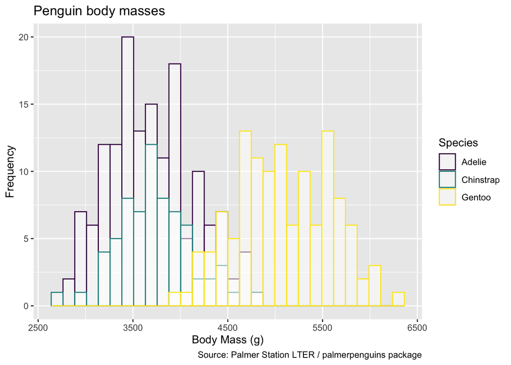

```r
penguins |>
  ggplot(aes(x = body_mass_g,
             color = species)) +
  geom_histogram(fill = "white", position = "identity", alpha = 0.5, ) +
  labs(
    title = "Penguin body masses",
    x = "Body Mass (g)",
    y = "Frequency",
    color = "Species",
    caption = "Source: Palmer Station LTER / palmerpenguins package") +
  scale_color_viridis_d()
```

Question 3:

➡️ Reproduce the box plot of the penguin body masses displayed below using ggplot2. Hint: to suppress the y-axis text and ticks, add a theme(axis.text.y = element_blank(), axis.ticks.y = element_blank()) layer to the plot.

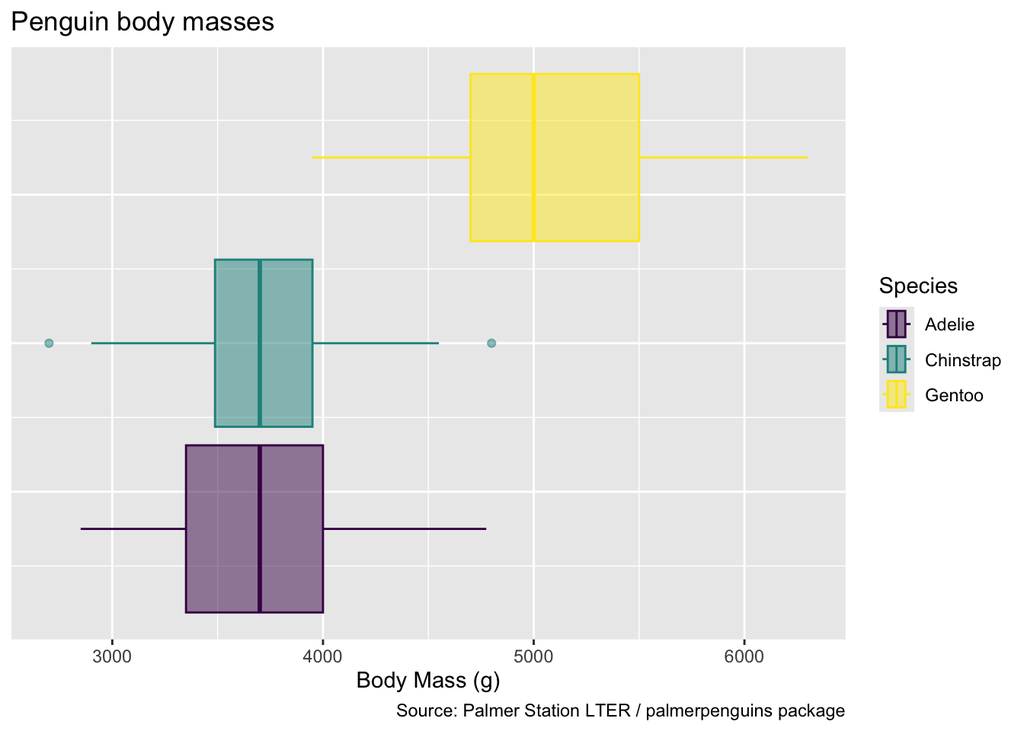

```r
penguins |>
  ggplot(aes(x = body_mass_g,
             color = species, fill = species)) +
  geom_boxplot(alpha = 0.5) +
  labs(
    title = "Penguin body masses",
    x = "Body Mass (g)",
    y = NULL,
    color = "Species",
    fill = "Species",
    caption = "Source: Palmer Station LTER / palmerpenguins package"
  ) +
  scale_color_viridis_d() +
  scale_fill_viridis_d() +
  theme(
    axis.text.y = element_blank(),
    axis.ticks.y = element_blank()
  )
```